# Geography 132 -- Assignment #3

**Ian Hinds**

### Instructions

> *While you're thinking about it, change the filename to match your name...*

> For this assignment you will run a particle tracking model to consider the risk of oil contaminating the shoreline under several environmental scenarios. The goals for this assignment are to:
> - experiment with running a numerical model and dealing with the output
> - interpret the observations in the context of range of physical drivers and how those conditions impact the behavior of a pollutant

#### The Situation

> You work for the [Marine Spill Response Corporation](https://www.msrc.org) as an environmental modeler. Your job is to run a suite of models (including oil degradation, weather forecasting, and ocean circulation) to provide the company's emergency response teams with real-time predictions of how an oil spill might evolve, so that assets can be effectively deployed to reduce the risk of coastaline contamination. The [Ocean Defender](https://www.marinetraffic.com/en/ais/details/ships/shipid:449976/mmsi:367546320/imo:0/vessel:OCEAN_DEFENDER), MSRC's fast-response vessel based out of Santa Barbara, has recently been re-crewed. The captain has asked you to provide the new crew with a report that describes the regional oceanography and the factors that affect the fate of oil in the marine environment. She'd like the report to talk about how atmospheric and oceanographic conditions generally change throughout the year in the context of the local oil seeps, because she knows the crew will have questions about the presence of oil at the surface during their training exercises. The captain also wants you to provide an example of your output for an actual oil spill, to illustrate the different impacts of a spill versus a seep.

> Further details of your report are included below.

# Hydrocarbons in the marine environment

> Synthesizing the readings (Ch. 4 in Weis) and lecture, provide a short introduction to hydrocarbons in the marine environment. In particular, describe the main characteristics that affect the fate of hydrocarbons (viscosity, volatility, and weight).

Natural Hydrocarbons are organic chemical compounds which form the base of important energy sources such as crude oil, natrual gas, and coal. They are created as a result of planktonic photosynthesis. Preservation of these hydrocarbons can be dependant on high sediment deposition rates and low bottom water dissolved oxygen, in which case they can be buried before oxidized or decomposed. Viscosity, flow potential, is impacted by tmeperature and pressure applied to the hydrocarbon as it changes the compound shape and density. Volatility, vaporization rate, is influenced by intermolecular forces which are impacted by the photosynthesis process. Weight of hydrocarbons depend on the continuous build up of molecular matter. These characterstics can be tracked by assessing the accumulation network, which include hysrocarbon source, accumulation terminal, the pathway connecting the termai and source, and the migration method potential. After a few human lifetimes, if not more, these hydrocarbons are compacted enough to be used as the energy sources the modern world heavily depend on.

# Circulation in the Santa Barbara Channel

> There are three synpotic patterns of circulation in the Santa Barbara Channel: upwelling, convergent, and relaxation. The basic ideas of this were laid out in [Harms & Winant, 1998](https://agupubs.onlinelibrary.wiley.com/doi/abs/10.1029/97JC02393) (see Fig. 10) and then considered in further detail by [Winant et al 2013](https://agupubs.onlinelibrary.wiley.com/doi/full/10.1029/2001JC001302) (see Fig. 5, top row). (The cyclonic eddy in the 1998 paper is termed convergent in the 2003 paper).

> Summarize these three states in a short narrative, including the typical season that these flow states tend to most frequently occur.

**Upwelling:**

Usually consists of equatorward flow from surface level to 45m depth, except in the area in Santa Barbara County that is adjacent to the main coastline. This pattern occurs mostly during Spring, March and April, when winds are upwelling avorable and pressure at the surface is constant.

**Convergent:**

Occurs during Summer, July-September, and consists of equatorward surface flow, and poleward flow at 45m depth. As a result of the flow convergence, the water body moves mostly in a offshore or westward direction. Winds during this pattern are strong and upwelling favorable and the variable upwelling has created surface pressure gradients alongshore.

**Relaxation:**

Often occuring during Winter, November-December. Water currents experience mostly polward flow from surface to 45m depth. In the Santa Barbara channel, much of this water can get trapped as poleward flow clashes with the majority of the coastline.

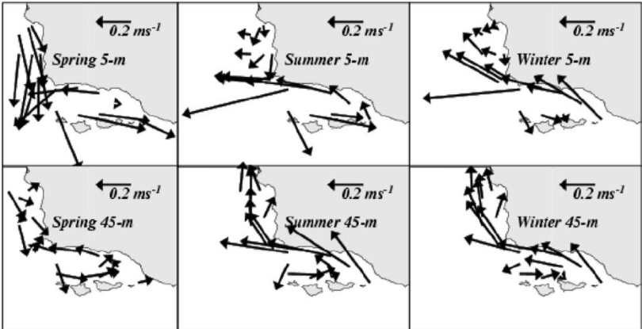

> To run the model, you will need to enter sea surface temperatures (SST) and wind speed/direction. Having taken Geography 132, you know that you can find climatic summaries for [NDBC buoy 46053](https://www.ndbc.noaa.gov/station_history.php?station=46053). You might find the synthesis paper from Fewing et al 2016 to be useful, as well.

> Fill in the folowing table summarizing the parameters used for your three circulation state models. You should reference/include the source of your observations. E.g. if you use information from the Fewings paper, you should cite that and include the reference in a *References* section. If you use data from the NDBC site, you should mention that and include the climatological graph.

[output not shown]

Source: NCBC Buoy 46053

# Fate of oil seeps

> Using [WebGNOME](https://gnome.orr.noaa.gov), NOAA's oil modeling application, illustrate how the fate of oil from the Coal Oil Point seep field differs under the three current scenarios above. For these three simulations, you should use a **constant** wind speed and direction (using the values in your table). The scenarios should be run for **five days**, using a seep rate of **160 barrels/day**.

> Include below maps showing the distribution of the plume after the five-day period.

**Upwelling**

[figure not shown]

**Relaxation**

[figure not shown]

**Convergent**

[figure not shown]

Source: NCBC Buoy 46053

> Discuss how the results are different, focusing particularly why/how the different variables in the table above affect the fate of oil along the coast.

**Variability**

The *WebGnome* model utilizes the changing variables of Wind Speed (kts) and Wind Direction (deg), and consistent variables of a 5-day timeline and 160 barrel/day volume. The Upwelling and Convergent models transport the oil across a large spatial extent. These models differed in both wind speed (11kt vs. 8kt) and direction (315deg vs. 260deg.), but still managed to transport extensively. The Relaxation model included winds at 9kts and 200 deg., but covered the least amount of water, and pressed mostly against the coastline neartest to the spill sight. Upwelling patterns tend to shift waters downcoast (equatorward), convergent patterns tend to circulate due to interfering currents, and relaxation patterns shift waters upcoast (poleward). As a result in this example, the relaxation cycle seeps into the land more densely than the other two patterns.

# Forecasting oil spills

> In contrast to the slow seeps above, create a realistic simulation for a spill of **800 barrels** coming from [Platform Holly](https://www.google.com/maps/place/Platform+Holly/@34.3898108,-119.9327176,13z/data=!4m5!3m4!1s0x0:0x9b529000e3714f56!8m2!3d34.3898108!4d-119.9064534). Run the simulation for **five days**, using the **NWS forecast** for the area.

**Holly Spill Model**

[figure not shown]

> Contrast your modeled spill results to the most applicable seep scenario. You should include and discuss the oil fate graphs for the spill and seep scenario. You should use the [25-hour mean sea surface currents](http://cordc.ucsd.edu/projects/mapping/maps/fullpage.php?ll=34.341863,-120.1786&zm=9&mt=terrain&rng=0.00,50.00&us=1&cs=4&res=6km_a&ol=&cp=1) to when considering which circulation state is most applicable. Modify the example HF Radar code provided on GauchoSpace (you can include that code here) or copy and paste a screen shot of the SCCOOS page here.

**25-hour Mean Sea Surface Current (3/24/2020)**

[figure not shown]

The above image, sourced from the *Consortium on the Ocean's Role in Climate* data model from the Scripps Institute at UCSD, represents the surface current average at the beginning of the Upwelling seep model example. Vectors are most intense in the south (equatorward) direction, and average downcoast currents, although there are several moderate upcoast vectors that cause interference. Comparing the manual input model featured in an above section, to this true measurement indicates a mostly upwelling current pattern. The 160 barrels/day volume reached the eastern coast of Sata Cruz Island in the manual model with 11kt winds at 315deg.

**25-hour Mean Sea Surface Current (3/16/2021)**

[figure not shown]

**Manual Upwelling vs. Realistic Platform Holly Spill**

Although both events can be categorized as having upwelling current patters, there are clear differences between the two scenarios. For example, with the manual scenario, Wind speed and Direction were inputted as one initial value, but the scenario timeline was set for 5-days. It is unlikely that the exact those exact variables would exist consistently within the 5-day period. The Realistic Holly scenario used *National Weather Service* forecasting to average out oceanic/atmospheric variables and therefore produce a more accurate visualization of oil transport. Additionally, when these models are compated to the CORC data models indicating the 25-hr surface current averages, the realistic scenario is more accurate. The manual upwelling model has limited accuracy due to the individual variables inputted with no variability over 5-days.